## Syllabus

Welcome to [HDFS 102](https://www.andrewdismukes.com/hdfs102).

Individual and Family Health, Development and Well-Being

## This is your syllabus presentation. Your lectures will have a similar format.

## Make sure to watch the introduction video!

## I’m Andrew, and I’ll be your instructor this semester.

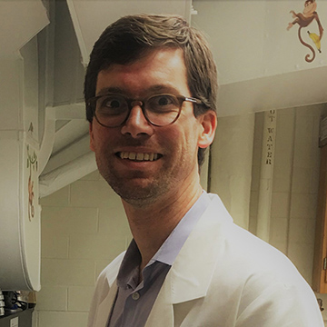

## Office hours and contact information:

Please get in touch with me with any questions or concerns you may have.

`Email:` dismukes@iastate.edu  
`Office Hours:` By Appointment

## Course Description

Welcome to HDFS 102. Individuals and families are extremely diverse, complex, and fascinating. This course provides an overview of life-span developmental tasks (physical, cognitive, language, social, emotional) examined from various theoretical perspectives. We will discuss topics related to family diversity, individual and family health and well-being, and reciprocal relationships. We will examine individual and family life theories, learn about human and family development as life-long, multidimensional processes, and make practical applications of contemporary research and course content.

## Student Learning Outcomes

- demonstrate knowledge of human development within the diverse social contexts of family, community, society, and culture.
- observe and document effects of major influences (physical, behavioral, socioemotional, cognitive) on the development of the individual within the family as they occur across the life span.
- demonstrate knowledge of the impact of structure, functioning, and sequencing in the development of families across the life span.
- effectively communicate an understanding of the process of change and the impact of decision-making on individual and family development.
- apply critical thinking skills to evaluate contemporary individual and family developmental issues.

## Student Learning Outcomes

- develop appreciation and exhibit respect for diversity, continuity, and adaptation as they relate to social justice issues within individual and family life development.
- reflect upon your own individual and family life development in relation to our course content.
- enhance your personal and professional lives by applying your knowledge of individual and family life development to your future experiences.

## The goal of this class is for you to learn. Because this is an online class, we will do more independent review than you would normally do in an in-person class.

## This is not busywork!

You have more freedom to learn the material when you choose, but you must treat this class with the same respect for time requirements that you would an in-person class. Excercises are **SPECIFICALLY** designed to focus and amplify core material and address common questions. NI expect as much or more of your time as you would spend in a brick and mortar class - that level of commitment is what I expect as well. It is necessary to learn this content.

## You need to spend time with the material

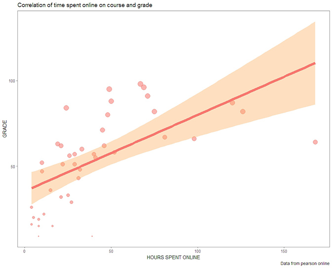

## Required Readings

Steinberg et al., 2010  
[Amazon Rental Link](https://www.amazon.com/Life-Span-Development-Adulthood-Developmental-Psychology-ebook/dp/B00B78HT9E/ref=mt_kindle?_encoding=UTF8&me=)

[figure not shown]

## Course Policies

I will detail the policy for this course as follows. Basically, don’t cheat and try to learn stuff.

## E-mail Policy

I am usually quick to respond to student e-mails. However, there are certain kinds of email that invariably get sent every semester, and that I will not prioritize. Please try to avoid the following:

1. Asking questions that could be answered by reading the syllabus.
2. Protesting a grade without reference to specific points of objection. See the policy on protesting a grade in the syllabus. Students interested in improving their knowledge of material should see me during office hours.
3. Asking to round up a grade. The answer is always “no”.
4. Asking for an extra credit opportunity not on the syllabus. The answer is “no”.

## Make-Up Exam Policy

There are **NO** make-ups for missed exams.

## Academic Integrity and Misconduct

High standards of academic honesty are expected in this course. Students are expected to complete their own work. The “ISU Academic Dishonesty Policy” is strictly enforced in this class. This policy may be found at: http://www.dso.iastate.edu/ja/academic/misconduct.html. Any form of cheating, plagiarism, or academic misconduct will result in referral to appropriate university personnel. Academic misconduct includes, but is not limited to, using work you submitted for another class without proper citations, using others’ work, and writing ideas, facts or opinions that are not your own, without citing the appropriate source. Other examples include: copying another student’s work; collaborating or sharing information with another student for completing tests or homework when not authorized to do so by the instructor; purchasing a paper from another student and submitting the work as your own; selling your work to another student; or having another student complete your work, quiz, in-class activity, or test.

## Harassment and Discrimination

Iowa State University strives to maintain our campus as a place of work and study for faculty, staff, and students that is free of all forms of prohibited discrimination and harassment based upon race, ethnicity, sex (including sexual assault), pregnancy, color, religion, national origin, physical or mental disability, age, marital status, sexual orientation, gender identity, genetic information, or status as a U.S. veteran. Any student who has concerns about such behavior should contact his/her instructor, Student Assistance at 515-294-1020, or email dso-sas@iastate.edu, or contact the Office of Equal Opportunity and Compliance at 515-294-7612.

## Special Accommodations

Iowa State University complies with the Americans with Disabilities Act and Sect 504 of the Rehabilitation Act. If you have a disability and anticipate needing accommodations in this course, please contact the course instructor to set up a meeting within the first two weeks of the semester or as soon as you become aware of your need. Before meeting with the instructor, you will need to obtain a SAAR form with recommendations for accommodations from the Disability Resources Office, located in Room 1076 on the main floor of the Student Services Building. Their telephone number is 515-294-7220 or email disability resources@iastate.edu. Retroactive requests for accommodations will not be honored.

## Religious Accommodation

If an academic or work requirement conflicts with your religious practices and/or observances, you may request reasonable accommodations. Your request must be in writing, and your instructor or supervisor will review the request. You or your instructor may also seek assistance from the Dean of Students Office or the Office of Equal Opportunity and Compliance.

## Dead Week Policy

This class follows the Iowa State University Dead Week policy as noted in section 10.6.4 of the Faculty Handbook: http://www.provost.iastate.edu/resources/faculty-handbook.

## Contact Information

If you are experiencing, or have experienced, a problem with any of the above issues, email: academicissues@iastate.edu

## Class Structure

## Overview

Each week, you will watch a video that introduces the course content. This video will be posted by Wednesday morning of each week and will be hosted on the course content website HERE. I will extend the book material in these videos, so it is critical that you read the chapter before watching the video - **this will be an extension, not a summary of the chapter**. You will submit questions from each weekly reading that you would like me to answer by Monday morning of the relevant week (see below). Furthermore, embedded in these videos will be quiz questions for you to answer. These questions will come up intermittently during the videos. I suggest that you pause the video and jot don your answer as you watch. You will submit your answers via blackboard to the weekly quizzes tab by Friday.

## Weekly Student Questions

I expect you to read every week. This is an excellent textbook and a wonderful learning resource. To this end, each week via blackboard, I expect you to submit two questions that emerged during your weekly readings. This is worth 15 percent of your final grade. I will review these questions each week and look for common themes or patterns that stand out, and try to address that in the weekly video. If you ask a particularly insightful question and it stands out I may choose to award a bonus point for that question. You will submit these questions through the weekly folders in blackboard. These are due Monday at 8 am.

## Weekly Quizzes

Each week I will ask a series of quiz questions during the weekly video. I suggest you pause your video and mark your answer. These will be multiple choice or short answer. I will ask these quiz questions randomly during the weekly video, and I **will not** provide the question on blackboard. This is to encourage you to review the video each week, and to highlight content I think is especially important. After you have written your 3-5 answers down, you can go to blackboard and submit your answers into the “Quiz Questions” assignment of the relevant week folder. This must be done by Friday at 11 pm.

## Assignments

You will have three assignments over the course of this semester. Assignments one and three will be personal reflections. Assignment two will be a child observation. All of these assignments will be uploaded via blackboard. Individual assignment instructions will be posted separately.

## Final Exam

Your final exam will be based on interview(s) you conduct, and reflection on what you learn in those interview(s). Final Exam instructions are posted separately.

## Grading Policy

- **25%** of your grade will be determined by weekly quizzes. *100 points out of 110 possible*
- **15%** of your grade will be determined by weekly submitted questions about the reading material. *60 points*
- **40%** of your grade will be determined by three semester assignments *160 points*
  - **10%** for assignment 1 *40 points*
  - **20%** for assignment 2 *80 points*
  - **10%** for assignment 3 *40 ponts*
- **20%** of your grade will be determined by your final exam. *80 points*

## Class Schedule

## Week 01, 08/21 - 08/25: Syllabus Week

- Read *all* associated documents on course content website for week one.
- Watch the syllabus introductory video.
- Read Chapter 1: The Study of Human Development
- Watch the Week 1 video.

## Week 02, 08/28 - 09/01: Chapter 2

- read Steinberg Chapter 2
- submit your week 2 questions no later than Monday at 8 am via Blackboard.
- Watch the Week 2 video.
- Review the Week 2 slides.
- submit your week 2 quiz answers no later than Friday at 11 pm via Blackboard.

## Week 03, 09/04 - 09/08: Chapter 3

- read Steinberg Chapter 3
- submit your week 3 questions no later than Tuesday (Monday is Labor Day) at 8 am via Blackboard.
- Watch the Week 3 video.
- Review the Week 3 slides.
- submit your week 3 quiz answers no later than Friday at 11 pm via Blackboard.

## Week 04, 09/11 - 09/15: Chapters 4

- read Steinberg Chapters 4
- submit your week 4 questions no later than Monday at 8 am via Blackboard.
- Watch the Week 4 video.
- Review the Week 4 slides.
- submit your week 4 quiz answers no later than Friday at 11 pm via Blackboard.
- Assignment 1 due by Friday at 11 pm.

## Week 05, 09/18 - 09/22: Chapters 5 & 6

- read Steinberg Chapters 5 & 6
- submit your week 5 questions no later than Monday at 8 am via Blackboard.
- Watch the Week 5 video.
- Review the Week 5 slides.
- submit your week 5 quiz answers no later than Friday at 11 pm via Blackboard.

## Week 06, 09/25 - 09/29: Chapters 7 & 8

- read Steinberg Chapters 7 & 8
- submit your week 6 questions no later than Monday at 8 am via Blackboard.
- Watch the Week 6 video.
- Review the Week 6 slides.
- submit your week 6 quiz answers no later than Friday at 11 pm via Blackboard.

## Week 07, 10/02 - 10/06: Chapter 9 & 10

- read Steinberg Chapter 9 & 10
- submit your week 7 questions no later than Monday at 8 am via Blackboard.
- Watch the Week 7 video.
- Review the Week 7 slides.
- submit your week 7 quiz answers no later than Friday at 11 pm via Blackboard.

## Week 08, 10/09 - 10/13: Chapter 11

- read Steinberg Chapter 11
- submit your week 8 questions no later than Monday at 8 am via Blackboard.
- Watch the Week 8 video.
- Review the Week 8 slides.
- submit your week 8 quiz answers no later than Friday at 11 pm via Blackboard.
- Assignment 2 due by Friday at 11 pm.

## Week 09, 10/16 - 10/20: Chapter 12

- read Steinberg Chapter 12
- submit your week 9 questions no later than Monday at 8 am via Blackboard.
- Watch the Week 9 video.
- Review the Week 9 slides.
- submit your week 9 quiz answers no later than Friday at 11 pm via Blackboard.

## Week 10, 10/23 - 10/27: Chapter 13

- read Steinberg Chapter 13
- submit your week 10 questions no later than Monday at 8 am via Blackboard.
- Watch the Week 10 video.
- Review the Week 10 slides.
- submit your week 10 quiz answers no later than Friday at 11 pm via Blackboard.

## Week 11, 10/30 - 11/03: Chapter 14

- read Steinberg Chapter 14
- submit your week 11 questions no later than Monday at 8 am via Blackboard.
- Watch the Week 11 video.
- Review the Week 11 slides.
- submit your week 11 quiz answers no later than Friday at 11 pm via Blackboard.

## Week 12, 11/06 - 11/10: Chapter 15 & 16

- read Steinberg Chapter 15 & 16
- submit your week 12 questions no later than Monday at 8 am via Blackboard.
- Watch the Week 12 video.
- Review the Week 12 slides.
- submit your week 12 quiz answers no later than Friday at 11 pm via Blackboard.

## Week 13, 11/13 - 11/17: Chapter 17

- read Steinberg Chapter 17
- submit your week 13 questions no later than Monday at 8 am via Blackboard.
- Watch the Week 13 video.
- Review the Week 13 slides.
- submit your week 13 quiz answers no later than Friday at 11 pm via Blackboard.

## Week 14, 11/20 - 11/24: Thanksgiving Holiday

## Week 15, 11/27 - 12/01: Chapters 18

- Assignment 3 due by Wednesday at 11 pm.
- submit your week 15 quiz answers no later than Friday at 11 pm via Blackboard.

## Week 16, 12/04 - 12/08: Dead Week

## Week 17, 12/11 - 12/15: Final Exam Week

- Final Exam due by Wednesday at 11 pm.